# BE 521: Homework 4 Questions

Spring 2024

66 points

Due: Feb 22nd, 2024

Objective: HFO detection and cross-validation

## HFO Dataset

High frequency oscillations (HFOs) are quasi-periodic intracranial EEG transients with durations on the order of tens of milliseconds and peak frequencies in the range of 80 to 500 Hz. There has been considerable interest among the epilepsy research community in the potential of these signals as biomarkers for epileptogenic networks.

In this homework exercise, you will explore a dataset of candidate HFOs detected using the algorithm of Staba et al. (see article on Canvas). The raw recordings from which this dataset arises come from a human subject with mesial temporal lobe epilepsy and were contributed by the laboratory of Dr. Greg Worrell at the Mayo Clinic in Rochester, MN.

The dataset `I521_A0004_D001` contains raw HFO clips that are normalized to zero mean and unit standard deviation but are otherwise unprocessed. The raw dataset contains two channels of data: Test_raw_norm and Train_raw_norm, storing raw testing and training sets of HFO clips respectively. The raw dataset also contains two annotation layers: Testing windows and Training windows, storing HFO clip start and stop times (in microseconds) for each of the two channels above. Annotations contain the classification by an "expert" reviewer (i.e., a doctor) of each candidate HFO as either an HFO (2) or an artifact (1). On ieeg.org and upon downloading the annotations, you can view this in the "description" field.

```python
!jupyter nbconvert --to html YuanchaoZhang_HW4.ipynb
```

```
[NbConvertApp] Converting notebook YuanchaoZhang_HW4.ipynb to html
[NbConvertApp] Writing 1867369 bytes to YuanchaoZhang_HW4.html
```

```python
#Set up the notebook environment
!pip install git+https://github.com/ieeg-portal/ieegpy.git # Install ieegpy toolbox directly from github
from ieeg.auth import Session
from IPython.display import Image
import matplotlib
import matplotlib.pyplot as plt
import numpy as np
from scipy import signal as sig
import datetime
import time
import sklearn
from sklearn.linear_model import LogisticRegression
from sklearn.svm import SVC
from sklearn.neighbors import KNeighborsClassifier
```

```
  Cloning https://github.com/ieeg-portal/ieegpy.git to /tmp/pip-req-build-53f94e04
  Running command git clone --filter=blob:none --quiet https://github.com/ieeg-portal/ieegpy.git /tmp/pip-req-build-53f94e04
  Resolved https://github.com/ieeg-portal/ieegpy.git to commit 080bfa42a8503380ef164b5e7b116613f75073bb
  Preparing metadata (setup.py) ... done
```

Let's familiarize ourselves with IEEG's annotation object.

1. From an IEEG `Dataset` object, we can call `.get_annotation_layers()`, which returns a dictionary where the keys are the names of the annotation layers, and the associated values are the number of annotations per layer.
2. We can load annotations from IEEG.org using the `.get_annotations(ANNOTATION_LAYER_NAME)` function. This returns a list of IEEG `Annotation` objects for the annotation layer you specified (by name).
3. The `Annotation` object itself has three important attributes:

> > `.description` tells you the value of the annotation (1 for Artifact, 2 for HFO)

> > `.start_time_offset_usec` tells you the starting timepoint of the annotation in microseconds

> > `.end_time_offset_usec` tells you the ending timepoint of the annotation in microseconds.

We give you a `load_annotations(dataset, annotation_layer_name)` function to easily load annotations from IEEG. This function takes two arguments: the IEEG `Dataset` object and the name of the annotation layer you want to load (given to you using `.get_annotation_layers()`). The function returns two objects. The first is an (n x 3) array with each of the n annotation's description, start_time_offset_usec, and end_time_offset_usec, respectively. The second is a list with the `Annotation` objects themselves.

```python
def load_annotations(dataset, annotation_layer_name):
  """
  Loads annotations for the specified annotation layer
  Input: 2 arguments
    dataset: the IEEG Dataset object
    annotation_layer_name: the name of the annotation layer (str)
  Returns: 2 objects
    (n x 3) numpy array. [i, :] contains the description, start_time_offset_usec, and end_time_offset_usec of annotation i, respectively.
    n-sized list. The raw output of the IEEG .get_annotations() function
  """
  #load the annotations
  annotations = dataset.get_annotations(annotation_layer_name)

  #container for annotation information. Set all default values to -1.
  anno_info = np.zeros((len(annotations), 3)) - 1

  #for each annotation, get the description, start and end times
  for i in range(len(annotations)):
    anno_info[i, 0] = annotations[i].description
    anno_info[i, 1] = annotations[i].start_time_offset_usec
    anno_info[i, 2] = annotations[i].end_time_offset_usec

  return [anno_info, annotations]
```

For convenience, we'll also give you `load_full_channels` again.

```python
def load_full_channels(dataset, duration_secs, sampling_rate, chn_idx):
  """
  Loads the entire channel from IEEG.org
  Input:
    dataset: the IEEG dataset object
    duration_secs: the duration of the channel, in seconds
    sampling_rate: the sampling rate of the channel, in Hz
    chn_idx: the indicies of the m channels you want to load, as an array-like object
  Returns:
    [n, m] numpy array of the channels' values.
  """
  #stores the segments of the channel's data
  chn_segments = []

  #how many segments do we expect?
  num_segments = int(np.ceil(duration_secs * sampling_rate / 6e5))

  #segment start times and the step
  seg_start, step = np.linspace(1, duration_secs*1e6, num_segments, endpoint=False, retstep=True)

  #get the segments
  for start in seg_start:
    chn_segments.append(dataset.get_data(start, step, chn_idx))

  #concatenate the segments vertically
  return np.vstack(chn_segments)
```

## 1. Simulating the SABA Detector (12 pts)

Candidate HFO clips were detected with the Staba et al. algorithm and subsequently validated by an expert as a true HFO or not. In this first section, we will use the original iEEG clips containing HFOs and re-simulate a portion of the Staba detection.

```python
with open('/content/Yua_ieeglogin.bin', 'r') as f:
  session = Session('Yuanchz1118', f.read())

# get the specified dataset from IEEG
dataset = session.open_dataset('I521_A0004_D001')

label = dataset.get_channel_labels()
index = dataset.get_channel_indices(label)
# print(index)

training_timeseries = dataset.get_time_series_details(label[1])
print(training_timeseries, "\n")
training_sample_rate = int(training_timeseries.sample_rate)
print("Smpling rate of the training set:",training_sample_rate, "Hz", "\n")

training_start_time = training_timeseries.start_time
training_end_time = training_timeseries.end_time

training_dataset_duration = training_timeseries.duration
print("Duration of the training set:", training_dataset_duration, "us \n")

### Training Set: label[1]
training_data = load_full_channels(dataset, training_dataset_duration / 10**6, training_sample_rate, [1])
print("The total number of the training set:", len(training_data))
```

```
None(Train_raw_norm) spans 4304122.0 usec, range [-22782-77053] in 140126 samples. Starts @1 uUTC, ends @4304123 uUTC with sample rate 32556.0 Hz and voltage conv factor 9.999999999999999e-06

Smpling rate of the training set: 32556 Hz

Duration of the training set: 4304122.0 us

The total number of the training set: 140125
```

### 1

How many samples exist for each class (HFO vs. artifact) in the training set? (Show code to support your answer.) (1 pts)

```python
# My code here

### Test Set: label[0]
### Training Set: label[1]
# layers = dataset.get_annotation_layers()
# print(layers)

### Get annotations from the training set depending on the certain layer
training_annotation = load_annotations(dataset, 'Training windows')
# print(training_annotation)

# print(training_annotation[0])
# print(training_annotation[0][1])
# print(training_annotation[0][0][2])
# print(len(training_annotation[0]))

### HFO (2)
HFO_Count = np.count_nonzero(training_annotation[0] == 2.0)
print("Samples exist for each class HFO:", HFO_Count)

### Artifact (1)
### Because the beginning of HFO's start_time_offset_usec = 1us(first row, second column),
### Count of HFO Annotations should -1 to except HFO's first start_time_offset_usec.
Artifact_Count = np.count_nonzero(training_annotation[0] == 1.0) - 1
print("Samples exist for each class artifact:", Artifact_Count)
```

```
Samples exist for each class HFO: 101
Samples exist for each class artifact: 99
```

**My Answer Here:**

Samples exist for each class HFO: **101**

Samples exist for each class artifact: **99**

### 2

Using the training set, find the first occurrence of the first valid HFO and the first artifact. Using `plt.subplots` with 2 plots, plot the HFO on the left and artifact on the right. (2 pts)

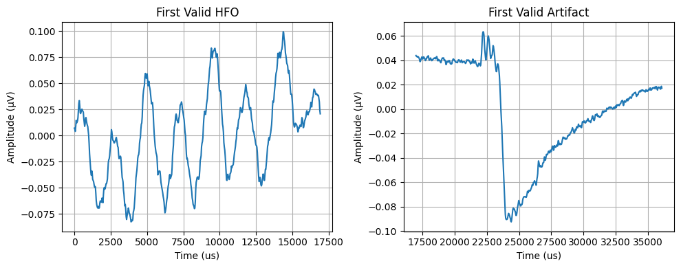

```python
# My code here
HFO_StartTime = training_annotation[0][0][1]
HFO_EndTime = training_annotation[0][0][2]
# first_HFO_data = load_full_channels(dataset, (HFO_EndTime - HFO_StartTime) / 10 ** 6, sample_rate, [1])
first_HFO_data = dataset.get_data(HFO_StartTime, HFO_EndTime - HFO_StartTime, [1])
# print(first_HFO_data.shape)
HFO_TimeRange = np.arange(HFO_StartTime, HFO_EndTime, (HFO_EndTime - HFO_StartTime)/len(first_HFO_data))

Artifact_StartTime = training_annotation[0][1][1]
Artifact_EndTime = training_annotation[0][1][2]
# first_Artifact_data = load_full_channels(dataset, (HFO_EndTime - HFO_StartTime) / 10 ** 6, sample_rate, index)
first_Artifact_data = dataset.get_data(Artifact_StartTime, Artifact_EndTime - Artifact_StartTime, [1])
Artifact_TimeRange = np.arange(Artifact_StartTime, Artifact_EndTime, (Artifact_EndTime - Artifact_StartTime)/len(first_Artifact_data))

# Plot the HFO and artifact clips side by side
fig, axs = plt.subplots(1, 2, figsize=(10, 4))
# Plot HFO
axs[0].plot(HFO_TimeRange, first_HFO_data)
axs[0].set_title('First Valid HFO')
axs[0].set_xlabel('Time (us)')
axs[0].set_ylabel('Amplitude (μV)')
axs[0].grid(True)

# Plot artifact
axs[1].plot(Artifact_TimeRange, first_Artifact_data)
axs[1].set_title('First Valid Artifact')
axs[1].set_xlabel('Time (us)')
axs[1].set_ylabel('Amplitude (μV)')
axs[1].grid(True)

plt.tight_layout()
plt.show()
```

### 3

Create an FIR bandpass filter of order 100 using [`firwin`](https://docs.scipy.org/doc/scipy/reference/generated/scipy.signal.firwin.html).

Use Staba et al. (2002) to guide your choice of passband and stopband frequency. Apply your filter using [`filtfilt`](https://docs.scipy.org/doc/scipy/reference/generated/scipy.signal.filtfilt.html) to the valid HFO and artifact clips obtained earlier. You will need to make a decision about the input arguments b and a in the `filtfilt` function. Plot these two filtered clips overlayed on their original signal in a two plot `subplot` as before. (6 pts)

> Hint: What does `firwin` return? How could you represent that as a fraction (or array of fractions)? What are the numerators and denominators of those fractions?

**My Answer Here:**

The Firwin function in Scipy.signal returns the coefficients of the finite impulse response (FIR) filter designed using the window method, yields an array with the FIR filter's numerator coefficients in particular.

The numerator coefficients represent the FIR filter's impulse response or how the filter reacts to an impulse input. These coefficients calculate the weighted sum of the previous input samples to create the current output sample.

**[1]** Band-pass filtered (80–500 Hz) events were used for power spectra calculations in A and B. This reduced the power associated with slow waves, contributing to the power spectra:

**Reference:**

**[1]** Staba, R. J., Wilson, C. L., Bragin, A., Fried, I., & Engel Jr, J. (2002). Quantitative analysis of high-frequency oscillations (80-500 Hz) recorded in human epileptic hippocampus and entorhinal cortex. Journal of Neurophysiology, 88(4), 1743-1752. https://doi.org/10.1152/jn.2002.88.4.1743

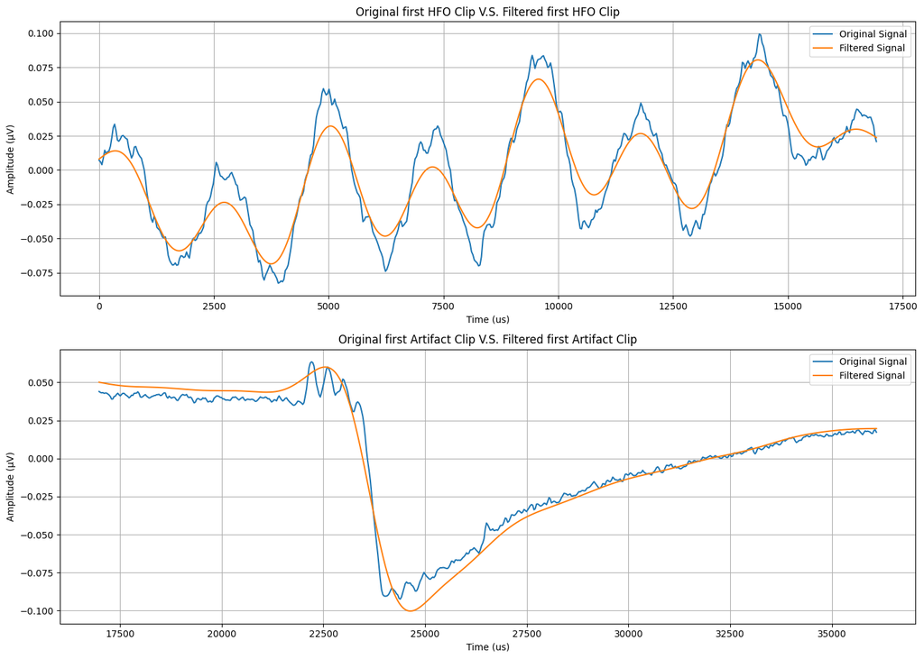

```python
# My code here
nyquist_freq = 0.5 * training_sample_rate
passband = [80.0, 500.0]
# stopband = [0.0, 80.0]

### Adjust frequencies in cutoff to be positive and monotonically increasing between 0 and fs/2
normalized_passband = [tmp_freq / nyquist_freq for tmp_freq in passband]
# normalized_stopband = [tmp_freq / nyquist_freq for tmp_freq in stopband]

order = 100
### Bandpass mode doesn't pass zero: pass_zero = 'false'
b = sig.firwin(order + 1, normalized_passband, window = 'hamming', pass_zero = 'bandpass')
# print(b)


a = [1]
# print(len(first_HFO_data))

### Apply the filter to the HFO and artifact clips obtained earlier
Filtered_HFO = sig.filtfilt(b, a, first_HFO_data, axis = 0, padlen = len(first_HFO_data) - 1)
# Filtered_HFO = sig.filtfilt(b, a, first_HFO_data, axis = 0, padlen = order + 1)
Filtered_Artifact = sig.filtfilt(b, a, first_Artifact_data, axis = 0, padlen = len(first_Artifact_data) - 1)
# Filtered_Artifact = sig.filtfilt(b, a, first_Artifact_data, axis = 0, padlen = order + 1)

# Plot the filtered clips overlayed on their original signal
fig, axs = plt.subplots(2, 1, figsize=(14, 10))

# Plot filtered HFO clip
axs[0].plot(HFO_TimeRange, first_HFO_data, label='Original Signal')
axs[0].plot(HFO_TimeRange, Filtered_HFO, label='Filtered Signal')
axs[0].set_xlabel('Time (us)')
axs[0].set_ylabel('Amplitude (μV)')
axs[0].set_title('Original first HFO Clip V.S. Filtered first HFO Clip')
axs[0].grid(True)
axs[0].legend()

# Plot filtered artifact clip
axs[1].plot(Artifact_TimeRange, first_Artifact_data, label='Original Signal')
axs[1].plot(Artifact_TimeRange, Filtered_Artifact, label='Filtered Signal')
axs[1].set_xlabel('Time (us)')
axs[1].set_ylabel('Amplitude (μV)')
axs[1].set_title('Original first Artifact Clip V.S. Filtered first Artifact Clip')
axs[1].grid(True)
axs[1].legend()

plt.tight_layout()
plt.show()
```

### 4

Speculate how processing the data using Staba's method may have erroneously led to a false HFO detection (3 pts)

**My Answer Here:**

Staba's approach to processing EEG data for high-frequency oscillation (HFO) identification has the potential to produce false positives for several reasons. These include the sensitivity of the algorithm to noise in the recordings, insufficient removal of artifacts from the signal processing, suboptimal tuning of the parameters, inability to distinguish true HFOs from interictal activity, subject variability in EEG recordings, and intrinsic limitations of the detection algorithm itself. To address these probable error causes, the algorithm may need to be refined to increase accuracy and decrease false detections. Careful validation and a detailed analysis of recognized events are also necessary.

## 2. Defining Features for HFOs (9 pts)

In this section we will be defining a feature space for the iEEG containing HFOs and artifacts. These features will describe certain attributes about the waveforms upon which a variety of classification tools will be applied to better segregate HFOs and artifacts

```python
# My code here
#print(training_annotation[0])
### raw_train_clip
i = 0
training_data = load_full_channels(dataset, training_dataset_duration / 10**6, training_sample_rate, [1])

testing_timeseries = dataset.get_time_series_details(label[0])
testing_dataset_duration = testing_timeseries.duration
testing_sample_rate = int(testing_timeseries.sample_rate)
testing_data = load_full_channels(dataset, testing_dataset_duration / 10**6, testing_sample_rate, [0])

#for i in range(len(training_annotation[0])):
#print(training_data)
#training_line_length = line_length(training_data)

#print(len(training_data) / training_sample_rate)
split_training_num = len(training_data) / training_sample_rate
# print(int(split_training_num) + 1)

## Sample rate of testing and training data is the same
print("Sampe rate of traning sample:", training_sample_rate)
print("Sampe rate of testing sample:", testing_sample_rate)
```

```
Sampe rate of traning sample: 32556
Sampe rate of testing sample: 32556
```

### 1

Create two new matrices, `trainFeats` and `testFeats`, such that the number of rows correspond to observations (i.e., number of training and testing clips) and the number of columns is two. Extract the line-length and area features (seen previously in lecture and Homework 3) from the normalized raw signals (note: use the raw signal from ieeg.org, do not filter the signal). Store the line-length value in the first column and area value for each sample in the second column of your features matrices. Make a scatter plot of the training data in the 2-dimensional feature space, coloring the valid detections blue and the artifacts red. (Note: Since we only want one value for each feature of each clip, you will effectively treat the entire clip as the one and only "window".) (4 pts)

```python
def line_length(x): return np.sum(np.absolute(np.ediff1d(x)))

def Area(x) : return np.sum(np.abs(x))

def CalculateFeats(x, featFn, index):

  # annotation_value_list = []
  featFn_List = []
  Artifacts_featFn_List = []
  Valid_Indices_List = []
  Artifact_Indices_List = []
  i = 0
  # split_sample_rate = training_sample_rate / len(x)
  # split_num = len(x) / sample_rate
  # print(len(training_data) / 32556)

  for i in range(len(x[0])):

    annotation_value = x[0][i][0]

    start_time = x[0][i][1]
    end_time = x[0][i][2]

    tmp_data = dataset.get_data(start_time, end_time - start_time, index)
    # tmp_data = load_full_channels(dataset, end_time - start_time, split_sample_rate * (i + 1), [1])

    tmp_data = [a for a in tmp_data if not np.isnan(a)]
    feat_value = featFn(tmp_data)
    featFn_List.append(feat_value)

    if (annotation_value == 2):
      #HFO_feat_value = featFn(tmp_data)
      #HFO_featFn_List.append(HFO_feat_value)
      Valid_Indices_List.append(i)

    elif (annotation_value == 1):
      #Artifacts_feat_value = featFn(tmp_data)
      #Artifacts_featFn_List.append(Artifacts_feat_value)
      Artifact_Indices_List.append(i)

  # featFn_List.remove(featFn_List[len(training_annotation[0]) - 1])
  return featFn_List, Valid_Indices_List, Artifact_Indices_List

# print(dataset.get_data(4.271655e+06, 4.304123e+06 - 4.271655e+06, [1]))
# training_ll_list, Valid_Indices_List, Artifact_Indices_List = CalculateFeats(training_data, line_length)
# print(len(training_ll_list))
# print(training_ll_list)
# print(Valid_Indices_List)
# print(len(Valid_Indices_List))
# print(Artifact_Indices_List)
# print(len(Artifact_Indices_List))
# print(training_annotation[0])
# print(len(training_annotation[0]))'''
```

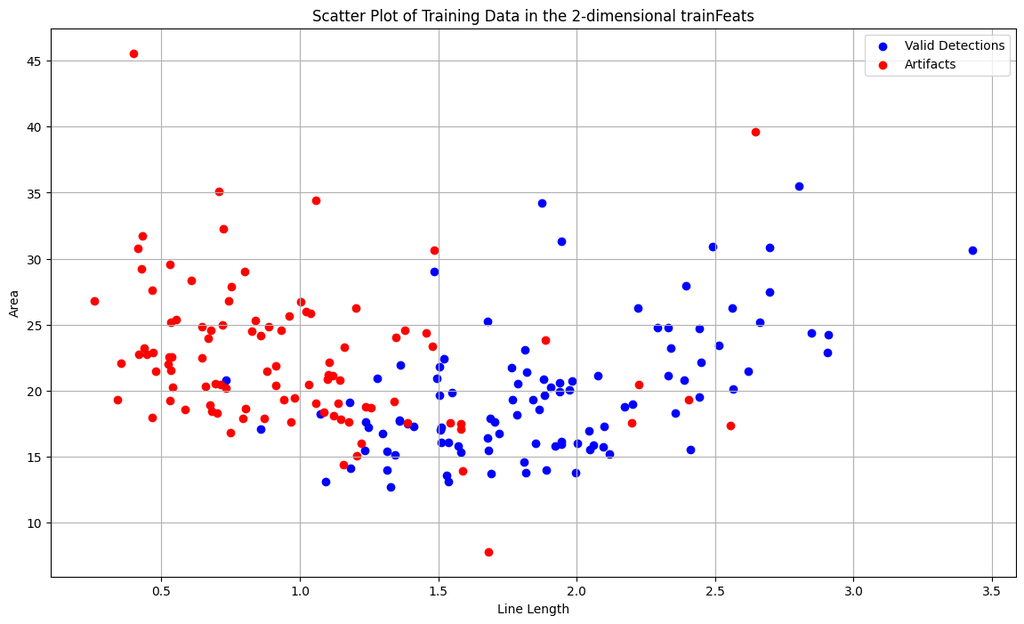

```python
training_ll_list, Training_Valid_Indices_List, Training_Artifact_Indices_List = CalculateFeats(training_annotation, line_length, [1])
# print(training_ll_list)
training_area_list, Training_Valid_Indices_List, Training_Artifact_Indices_List = CalculateFeats(training_annotation, Area, [1])
# print(training_area_list)

testing_annotation = load_annotations(dataset, 'Testing windows')

testing_ll_list, Testing_Valid_Indices_List, Testing_Artifact_Indices_List = CalculateFeats(testing_annotation, line_length, [0])
# print(testing_ll_list)
testing_area_list, Testing_Valid_Indices_List, Testing_Artifact_Indices_List = CalculateFeats(testing_annotation, Area, [0])
# print(testing_area_list)

# Create matrices trainFeats and testFeats
training_ll_arr = np.array(training_ll_list)
training_area_arr = np.array(training_area_list)
trainFeats = np.column_stack((training_ll_arr, training_area_arr))
# print("First Metric of training data's features:\n", trainFeats, "\n")

testing_ll_arr = np.array(testing_ll_list)
testing_area_arr = np.array(testing_area_list)
testFeats = np.column_stack((testing_ll_arr, testing_area_arr))
# print("Second Metric of testing data's features:\n", testFeats)

# print(len(trainFeats))
# print(len(training_annotation[0]))
# print(trainFeats[:, 0])
# print(trainFeats[:, 1])

HFO_trainFeats_list = []
Artifact_trainFeats_list = []
# print(len(trainFeats))

HFO_trainFeats_Array = np.zeros(len(trainFeats))
Artifact_trainFeats_Array = np.zeros(len(trainFeats))

for t1 in Training_Valid_Indices_List:
  HFO_trainFeats_list.append(trainFeats[t1].tolist())
for t2 in Training_Artifact_Indices_List:
  Artifact_trainFeats_list.append(trainFeats[t2].tolist())

# print(len(HFO_trainFeats_list))
# print(len(Artifact_trainFeats_list))
HFO_ll_list = []
HFO_area_list = []
Artifact_ll_list = []
Artifact_area_list = []
for x in range(len(HFO_trainFeats_list)):
  HFO_ll_list.append(HFO_trainFeats_list[x][0])
  HFO_area_list.append(HFO_trainFeats_list[x][1])
for y in range(len(Artifact_trainFeats_list)):
  Artifact_ll_list.append(Artifact_trainFeats_list[y][0])
  Artifact_area_list.append(Artifact_trainFeats_list[y][1])

# Scatter plot of the training data in the 2-dimensional feature space
plt.figure(figsize=(14, 8))

plt.scatter(HFO_ll_list, HFO_area_list, color='blue', label='Valid Detections')
plt.scatter(Artifact_ll_list, Artifact_area_list, color='red', label='Artifacts')

plt.xlabel('Line Length')
plt.ylabel('Area')
plt.title('Scatter Plot of Training Data in the 2-dimensional trainFeats')
plt.grid(True)
plt.legend()
plt.show()
```

### 2

Feature normalization is often important. One simple normalization method is to subtract each feature by its mean and then divide by its standard deviation (creating features with zero mean and unit variance). Using the means and standard deviations calculated in your *training* set features, normalize both the training and testing sets. You should use these normalized features for the remainder of the assignment.

```python
# My code here

# print(trainFeats)
# print(testFeats)

i = 0
j = 0
train_ll_list = []
train_area_list = []

### Step 1: Calculate mean and standard deviation for each feature in the training set
for i in range(len(trainFeats)):
  train_ll_list.append(trainFeats[i][0])

train_ll_mean = np.mean(train_ll_list)
train_ll_std = np.std(train_ll_list)
# print(train_ll_std)

for j in range(len(trainFeats)):
  train_area_list.append(trainFeats[j][1])

train_area_mean = np.mean(train_area_list)
train_area_std = np.std(train_area_list)
# print(train_area_std)

train_mean_statis = np.column_stack((train_ll_mean, train_area_mean))
# print(train_mean_statis)
train_std_statis = np.column_stack((train_ll_std, train_area_std))
# print(train_std_statis)

# Step 2: Subtract mean of trainFeats in both trainFeats and testFeats
normalized_trainFeats = (trainFeats - train_mean_statis)
normalized_testFeats = (testFeats - train_mean_statis)

# Step 3: Divide trainFeats and testFeats by standard deviation of trainFeats
normalized_trainFeats = normalized_trainFeats / train_std_statis
normalized_testFeats = normalized_testFeats / train_std_statis
# print(testing_annotation[0])
# print(testFeats)
# print(len(normalized_trainFeats))
# print(len(normalized_testFeats))
```

#### 2a

What is the statistical term for the normalized value, which you have just computed? (1 pts)

**My Answer Here:**

My calculation of the statistical term for the normalized values after standardization is referred to as : **Z-Scores**.

The calculation formula is roughly defined as: **Z = (x-μ)/σ**

```python
# My code here
# print("Statistical term for the Normalized Mean of Train Features:", train_mean_statis, "\n")
# print("Statistical term for the Normalized Standard Deviation of Train Features:", train_std_statis, "\n")

# print("Statistical term for the Normalized Train Features:\n", normalized_trainFeats, "\n")
# print("Statistical term for the Normalized Test Features:\n", normalized_testFeats)
```

#### 2b

Explain why such feature normalization might be critical to the performance of a *k*-NN classifier. (2 pts)

**My Answer Here:**

A k-NN (k-Nearest Neighbors) classifier's performance depends on feature normalization since it uses **nearest. distance-based computations**.

A data point in k-NN is classified based on the majority class of its k-nearest neighbors in the feature space. On the other hand, larger scales or character variations may predominate in the distance computations if we don't normalize these variations in the raw train features; fluctuated distances would produce biased outcomes. We normalize features with a zero mean and unit variance to ensure that each feature contributes equally to the distance computations. **As a result, such feature normalization enables the k-NN classifier to generate more trustworthy and accurate predictions with more consistent distance changes to improve total performance.**

Generally, feature normalization plays a crucial role in enhancing the robustness and effectiveness of the k-NN method.

#### 2c

Explain why you use the training feature means and standard deviations to normalize the testing set. (2 pts)

**My Answer Here:**

The training and testing sets are standardized using the means and standard deviations from the training set to ensure uniformity in the normalization process across the two datasets. This consistency is necessary to protect the model's learning process and prevent unintended information leakage from the testing set into the training phase, which might lead to overfitting. By normalizing the testing set with the same parameters as the training set, we ensure that the model is evaluated on data that has undergone the same changes as the training data. This methodology enhances the model's generalization abilities and overall efficacy by imitating real-world scenarios when predictions are made on yet-to-be-observed data.

## 3. Comparing Classifiers (20 pts)

In this section, you will explore how well a few standard classifiers perform on this dataset.

### 1

Using [`LogisticRegression`](https://scikit-learn.org/stable/modules/generated/sklearn.linear_model.LogisticRegression.html) with its default parameters, train a model on the training set and calculate its training [`score`](https://scikit-learn.org/stable/modules/generated/sklearn.linear_model.LogisticRegression.html#sklearn.linear_model.LogisticRegression.score). What does this score tell you? (3 pts)

```python
# My code here
# print(len(train_mean_statis))
# print(len(testFeats))
# print(len(testing_ll_list))

train_label_list = []
i = 0
for i in range(len(training_annotation[0])):
  annotation_value = training_annotation[0][i][0]
  train_label_list.append(annotation_value)

# x_normalized_train = np.column_stack((label_list, normalized_trainFeats))
# y_train_arr = np.zeros()
LR_model = LogisticRegression().fit(normalized_trainFeats, train_label_list)
LR_Training_Score = LR_model.score(normalized_trainFeats, train_label_list)
print("Using LogisticRegression, Training Score on the training set:", LR_Training_Score)
```

```
Using LogisticRegression, Training Score on the training set: 0.875
```

**My Answer Here:**

Training Score of LogisticRegression: **0.875**

**A training score of 0.875** indicates that the model almost accurately predicts the target variable for around 87.5% of the samples in the training dataset. When interpreting this score, care must be taken, though, as it may be **a sign of overfitting**; in this case, the model may have performed poorly in generalization on unobserved data because it may have just remembered the training set rather than discovering underlying patterns.

### 2

Using the model trained on the training data, calculate the model's score on the testing set. Is the testing error larger or smaller than the training error? Give one sentence explaining why this might be so. (2 pts)

```python
# My code here
test_label_list = []
j = 0

# print(len(normalized_testFeats))
# testing_annotation = load_annotations(dataset, 'Testing windows')
# print(len(testing_annotation[0]))

for j in range(len(testing_annotation[0])):
  annotation_value = testing_annotation[0][j][0]
  test_label_list.append(annotation_value)
# print(test_label_list)

LR_Testing_Score = LR_model.score(normalized_testFeats, test_label_list)
print("Using LogisticRegression, Testing Score on the testing set:", LR_Testing_Score)
```

```
Using LogisticRegression, Testing Score on the testing set: 0.8690476190476191
```

**My Answer Here:**

Testing Score of LogisticRegression: **0.8690476190476191**

The testing error is **larger than** the training error because of the model's ability to memorize or overfit the specific patterns present in the training data, which may not fully generalize to unseen data in the test set.

### 3

Make a k-nearest neighbors classifier, with *k* = 1, using the [`KNeighborsClassifier`](https://scikit-learn.org/stable/modules/generated/sklearn.neighbors.KNeighborsClassifier.html) function. You can leave the other parameters at their default values.

```python
# My code here
KNN_model = KNeighborsClassifier(n_neighbors = 1)
KNN_model.fit(normalized_trainFeats, train_label_list)
```

```
KNeighborsClassifier(n_neighbors=1)
```

#### 3a

Calculate the training and testing scores of this model. (3 pts)

```python
# My code here
KNN_Training_Score = KNN_model.score(normalized_trainFeats, train_label_list)
print("Using k-nearest neighbors classifier, Training Score on the training set:", KNN_Training_Score)

KNN_Testing_Score = KNN_model.score(normalized_testFeats, test_label_list)
print("Using k-nearest neighbors classifier, Testing Score on the testing set:", KNN_Testing_Score)
```

```
Using k-nearest neighbors classifier, Training Score on the training set: 1.0
Using k-nearest neighbors classifier, Testing Score on the testing set: 0.8214285714285714
```

Your answer here

Training Score of k-nearest neighbors classifier: **1.0**

Testing Score of k-nearest neighbors classifier: **0.8214285714285714**

#### 3b

Why is the training error zero? (2 pts)

**My Answer Here:**

When employing a k-nearest neighbors classifier with k=1, the training error is 0, as **every training sample is its nearest neighbor**, producing flawless classification for every training example. In this case, the model indeed accurately learns the training set, correctly classifying every point to the appropriate class throughout training.

### 4

Now, train a support vector machine (SVM) with the [`SVC`](https://scikit-learn.org/stable/modules/generated/sklearn.svm.SVC.html) function. Use the RBF kernel, and keep the other parameters at their default values. Report the training and testing scores for the model. (3 pts)

```python
# My code here
# Initialize and train the SVM model with RBF kernel and default parameters
SVM_model = SVC(kernel='rbf')
SVM_model.fit(normalized_trainFeats, train_label_list)

# Calculate training and testing scores
SVM_training_score = SVM_model.score(normalized_trainFeats, train_label_list)
SVM_testing_score = SVM_model.score(normalized_testFeats, test_label_list)

print("Using Support Vector Machine (SVM), Training Score =", SVM_training_score)
print("Using Support Vector Machine (SVM), Testing Score =", SVM_testing_score)
```

```
Using Support Vector Machine (SVM), Training Score = 0.885
Using Support Vector Machine (SVM), Testing Score = 0.8857142857142857
```

**My Answer Here:**

Training Score of Support Vector Machine (SVM): **0.885**

Testing Score of Support Vector Machine (SVM): **0.8857142857142857**

### 5

It is sometimes useful to visualize the decision boundary of a classifier. To do this, we'll plot the classifier's prediction value at every point in the "decision" space. Use the [`meshgrid`](https://numpy.org/doc/stable/reference/generated/numpy.meshgrid.html#numpy.meshgrid) function to generate points in the line-length and area 2D feature space, and a scatter plot (with the `'.'` point marker) to visualize the classifier decisions at each point. Use yellow for Artifacts and cyan for HFOs for your colors. In the same plot, show the training samples, plotted with the `'*'` marker to make them more visible. As before, use blue for the HFOs and red for the artifacts. Use ranges of features that encompasses all training points and a density that is sufficiently high to make the decision boundaries clear.

Do this for the logistic regression, *k*-NN and SVM classifiers. (4 pts)

**Reference:**

**[1]** https://hackernoon.com/how-to-plot-a-decision-boundary-for-machine-learning-algorithms-in-python-3o1n3w07

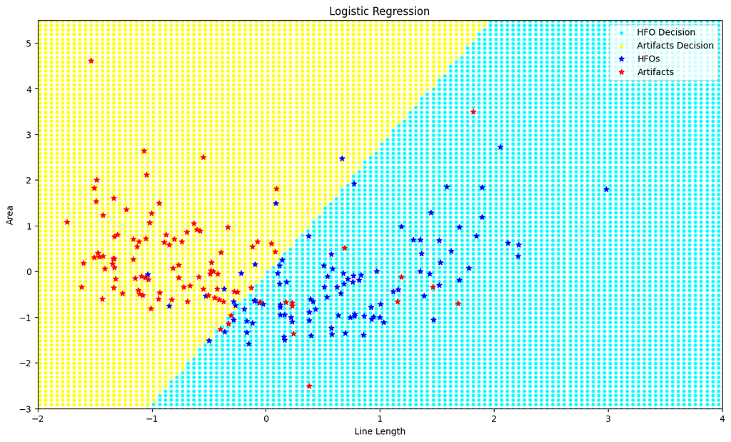

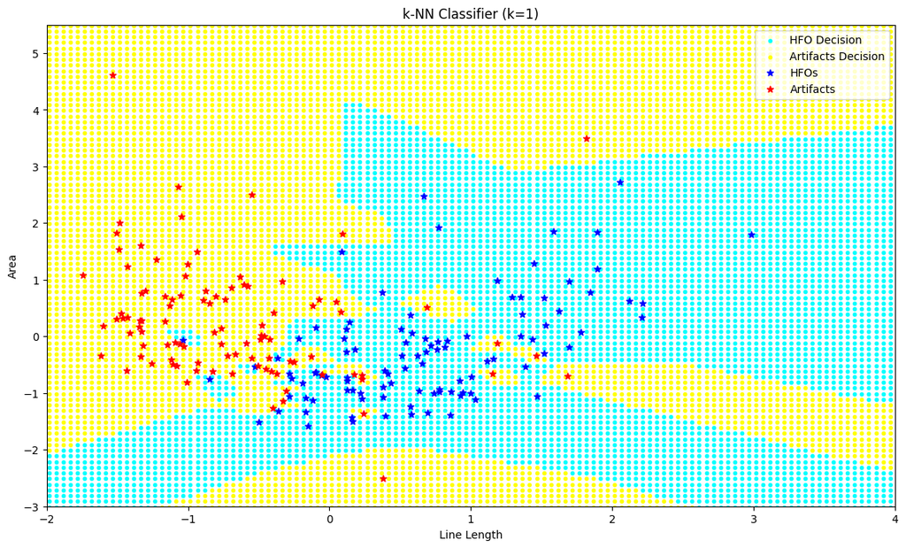

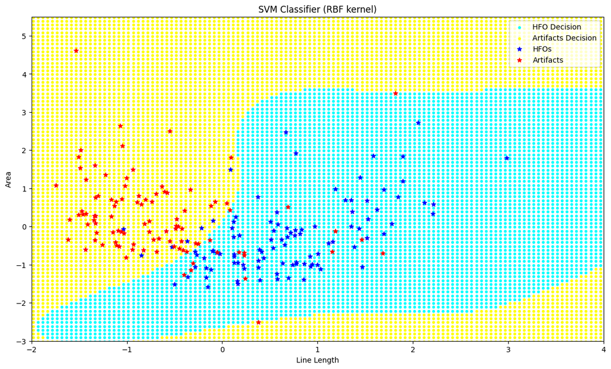

```python
Normalize_HFO_ll = (HFO_ll_list - train_ll_mean) / train_ll_std
# print(Normalize_HFO_ll)
Normalize_HFO_area = (HFO_area_list - train_area_mean) / train_area_std
# print(Normalize_HFO_area)
Normalize_Artifact_ll = (Artifact_ll_list - train_ll_mean) / train_ll_std
Normalize_Artifact_area = (Artifact_area_list - train_area_mean) / train_area_std

# Define a function to plot decision boundaries and training samples
def plot_decision_boundary(classifier, X, X_HFO, y_HFO, X_Artifact, y_Artifact, label_list, title):
    # h_x = 0.05  # Step size in the mesh
    # h_y = 0.1
    # Define custom colormap arrays
    # cmap_light = matplotlib.colors.LinearSegmentedColormap.from_list("", ["yellow","cyan"])  # Cyan for HFO Decision, Yellow for Artifact Decision

    # Plot the decision boundary
    # define bounds of the domain
    # x_min, x_max = X[:, 0].min()-1, X[:, 0].max()+1
    x_min, x_max =  X_HFO.min() - 1, X_HFO.max() + 1
    # x_min, x_max = X[:, 1].min()-1, X[:, 1].max()+1
    y_min, y_max = y_Artifact.min() - 1, y_Artifact.max() + 1

    # define the x and y scale
    x1_grid = np.arange(x_min, x_max, 0.05)
    x2_grid = np.arange(y_min, y_max, 0.1)

    # create all of the lines and rows of the grid
    xx, yy = np.meshgrid(x1_grid, x2_grid)

    ### horizontal stack vectors to create x1,x2 input for the model
    ### Search on the Internet: grid = np.c_[xx.ravel(), yy.ravel()]
    stack_1, stack_2 = xx.flatten(), yy.flatten()
    stack_1, stack_2 = stack_1.reshape((len(stack_1), 1)), stack_2.reshape((len(stack_2), 1))
    grid = np.hstack((stack_1,stack_2))
    y_pred = classifier.predict(grid)
    # print(xx.shape)
    # zz = y_pred.reshape(xx.shape)

    xx_HFO = grid[np.where(y_pred == 2), 0]
    yy_HFO = grid[np.where(y_pred == 2), 1]
    xx_Artifact = grid[np.where(y_pred == 1), 0]
    yy_Artifact = grid[np.where(y_pred == 1), 1]

    # plot the grid of x, y and z values as a surface
    # plt.contourf(xx, yy, zz, cmap = cmap_light, marker = '.')
    # plt.pcolormesh(xx, yy, zz, cmap = cmap_light)
    plt.scatter(xx_HFO, yy_HFO, color = 'cyan', marker = '.', label = 'HFO Decision')
    plt.scatter(xx_Artifact, yy_Artifact, color = 'yellow', marker = '.', label = 'Artifacts Decision')

    plt.scatter(X_HFO, y_HFO, color = 'blue', marker = '*', label = 'HFOs')
    plt.scatter(X_Artifact, y_Artifact, color = 'red', marker = '*', label = 'Artifacts')

    plt.xlabel('Line Length')
    plt.ylabel('Area')
    plt.xlim(-2, 4)
    plt.ylim(-3, 5.5)
    plt.title(title)
    plt.legend()
    plt.show()

# print(normalized_trainFeats[:, 1])
# Plot decision boundaries
plt.figure(figsize = (14, 8))
plot_decision_boundary(LR_model, normalized_trainFeats, Normalize_HFO_ll, Normalize_HFO_area, Normalize_Artifact_ll, Normalize_Artifact_area, train_label_list, 'Logistic Regression')
plt.figure(figsize = (14, 8))
plot_decision_boundary(KNN_model, normalized_trainFeats, Normalize_HFO_ll, Normalize_HFO_area, Normalize_Artifact_ll, Normalize_Artifact_area, train_label_list, 'k-NN Classifier (k=1)')
plt.figure(figsize = (14, 8))
plot_decision_boundary(SVM_model, normalized_trainFeats, Normalize_HFO_ll, Normalize_HFO_area, Normalize_Artifact_ll, Normalize_Artifact_area, train_label_list, 'SVM Classifier (RBF kernel)')
plt.show()
```

### 6

In a few sentences, report some observations about the three plots, especially similarities and differences between them. Which of these has overfit the data the most? Which has underfit the data the most? (3 pts)

**My Answer Here:**

According to my observation of the previous three plots, the boundary of the K-NN Classifier(K=1) is most dispersive, thus **the K-NN Classifier(k=1) overfits the data at most.**

While the Logistic Regression boundary is smooth, **Logistic Regression underfits its the data at most.**

## 4. Cross-Validation (26 Pts)

In this section, you will investigate the importance of cross-validation, which is essential for choosing the tunable parameters of a model (as opposed to the internal parameters the classifier "learns" by itself on the training data).

### 1

Since you cannot do any validation on the testing set, you'll have to split up the training set. One way of doing this is to randomly split it into k unique "folds," with roughly the same number of samples (n/k for n total training samples). Then you can create different training and validation splits, using k-1 of the folds as training data and the remaining fold as validation data. In this question, you will perform 10-fold cross-validation.

Use [`KFold`](https://scikit-learn.org/stable/modules/generated/sklearn.model_selection.KFold.html) and [`.split()`](https://scikit-learn.org/stable/modules/generated/sklearn.model_selection.KFold.html#sklearn.model_selection.KFold.split) to create 10 random train/validation splits using the training data only.

#### 1a

How are these splits represented using `KFold`? How are they related to the folds? (1 pt)

Hint: Look at the next question if you're unsure

**My Answer Here:**

The splits are related to the folds in the sense that each fold represents a distinct subset of the data used for validation: The first parameter of KFold requires us to input "n_splits"(the number of splits) which equivalently represents the number of folds. Because we will perform 10 random train/validation splits, the number of folds should also equal to 10.

#### 1b

Create a list to hold the indices of each of these splits, something of the form `[(training_indices, testing_indices), (training_indices, testing_indices), ...]`. How many training and testing examples are in each split? Is that expected? (1 pt)

```python
from sklearn.model_selection import KFold
# My code here
# kf = KFold(n_splits = 10)
# kf.get_n_splits(normalized_trainFeats)

# print(train_kf)

kf = KFold(n_splits = 10, random_state = 42, shuffle = True)
train_splits_indices_list = []
test_splits_indices_list = []

# print(kf.split(normalized_trainFeats))
# print(enumerate(kf.split(normalized_trainFeats)))

for split, (train_indices, test_indices) in enumerate(kf.split(normalized_trainFeats)):
  num_train_examples = len(train_indices)
  num_test_examples = len(test_indices)
  print(f"Split #{split + 1}:\n")
  print(f"  Training Indices = {train_indices}\n")
  print(f"  Testing Indices = {test_indices}")
  print("___________________________________________________________________________________________\n\n\n")

print("Number of training examples in each split:", num_train_examples)
print("Number of testing examples in each split:", num_test_examples)
```

```
Split #1:

  Training Indices = [  0   1   2   3   4   5   6   7   8   9  10  11  12  13  14  16  17  18
  19  20  21  22  23  24  25  26  27  28  29  31  32  33  34  35  36  37
  38  39  40  41  42  43  44  46  47  48  49  50  51  52  53  54  55  57
  58  59  60  61  62  63  64  65  67  70  71  72  73  74  75  76  77  79
  80  81  83  84  85  86  87  88  89  90  91  92  93  94  96  97  98  99
 100 101 102 103 104 105 106 107 108 109 110 111 112 113 114 116 117 118
 119 120 121 122 123 124 125 126 127 129 130 131 132 133 134 135 136 137
 138 139 140 141 142 143 144 145 146 147 148 149 150 151 153 154 155 156
 157 159 160 161 162 163 164 166 167 168 169 171 172 173 175 176 178 179
 180 181 183 184 185 187 188 189 190 191 192 193 194 195 196 197 198 199]

  Testing Indices = [ 15  30  45  56  66  68  69  78  82  95 115 128 152 158 165 170 174 177
 182 186]
___________________________________________________________________________________________



Split #2:

  Training Indices = [  0   1   2   3   4   5   6   7   8  10  11  12  13  14  15  17  19  20
  21  22  23  24  25  26  27  28  29  30  31  32  33  34  35  36  37  38
  39  40  41  42  43  44  45  46  47  48  49  50  51  52  53  54  56  57
  58  59  61  62  63  64  66  68  69  70  71  72  73  74  77  78  79  80
  81  82  83  85  86  87  88  89  90  91  92  94  95  96  97  98  99 100
 101 102 103 105 106 107 108 109 110 111 112 113 114 115 116 117 118 119
 120 121 122 123 126 127 128 129 130 131 133 134 136 138 139 140 141 142
 143 144 145 146 147 149 151 152 153 154 155 156 157 158 159 160 161 162
 163 165 166 167 168 169 170 171 172 173 174 175 176 177 178 179 180 181
 182 183 184 185 186 187 188 189 190 191 192 193 194 195 196 197 198 199]

  Testing Indices = [  9  16  18  55  60  65  67  75  76  84  93 104 124 125 132 135 137 148
 150 164]
___________________________________________________________________________________________



Split #3:

```

[output cut: 137 more lines]

```
  78  79  80  81  82  83  84  85  86  88  89  90  91  93  94  95  96  97
  98 100 101 104 105 107 108 109 110 111 112 113 114 115 117 118 119 120
 122 123 124 125 126 127 128 129 131 132 133 134 135 136 137 138 139 140
 141 142 143 144 145 146 147 148 150 152 153 154 155 156 157 158 159 160
 161 162 163 164 165 166 167 168 169 170 171 172 173 174 175 176 177 178
 180 181 182 183 184 185 186 187 189 190 191 192 193 194 195 196 197 198]

  Testing Indices = [  1  14  20  52  71  74  87  92  99 102 103 106 116 121 130 149 151 179
 188 199]
___________________________________________________________________________________________



Number of training examples in each split: 180
Number of testing examples in each split: 20
```

**My Answer Here:**

Number of training examples in each split: **180**

Number of testing examples in each split: **20**

**Yes, the results of the splits fit my expectations!**

### 2

Train new *k*-NN models (with the same parameters as before) on each of the 10 folds.

#### 2a

Report the validation score for each model on their respective splits. (3 pts)

```python
# My code here
# Parameters for k-NN model
#### n_neighbors = 1

validation_score_list = []
train_label_arr = np.array(train_label_list)
test_label_arr = np.array(test_label_list)

for knn_split, (knn_train_indices, knn_test_indices) in enumerate(kf.split(normalized_trainFeats)):
    # Split the data into training and validation sets for this fold
    split_normalized_testFeats = normalized_testFeats[knn_test_indices]
    # split_normalized_trainFeats = normalized_trainFeats[knn_train_indices]
    # print(split_normalized_trainFeats)


    split_validation_label = test_label_arr[knn_test_indices]
    # split_validation_label = train_label_arr[knn_test_indices]
    # print(split_validation_label)

    KNN_Validation_Score = KNN_model.score(split_normalized_testFeats, split_validation_label)
    validation_score_list.append(KNN_Validation_Score)
    # print("Using k-nearest neighbors classifier, Training Score on the training set:", KNN_Training_Score)

    ### Consistently display four digits of validation score
    print(f"Split #{knn_split + 1} Validation Score: {validation_score_list[knn_split]:.4f}")
```

```
Split #1 Validation Score: 0.8000
Split #2 Validation Score: 1.0000
Split #3 Validation Score: 0.8500
Split #4 Validation Score: 0.7000
Split #5 Validation Score: 0.7000
Split #6 Validation Score: 0.7500
Split #7 Validation Score: 0.8500
Split #8 Validation Score: 0.8500
Split #9 Validation Score: 0.8000
Split #10 Validation Score: 0.8000
```

**My Answer Here:**

Validation Score for **1st** split: **0.8000**

Validation Score for **2nd** split: **1.0000**

Validation Score for **3rd** split: **0.8500**

Validation core for **4th** split: **0.7000**

Validation Score for **5th** split: **0.7000**

Validation Score for **6th** split: **0.7500**

Validation Score for **7th** split: **0.8500**

Validation Score for **8th** split: **0.8500**

Validation Score for **9th** split: **0.8000**

Validation Score for **10th** split: **0.8000**

**Note: The Validation Score of each split may change in different simulations, thus My Answer Here might be different from printed results above.**

#### 2b

Calculate the average validation score. How does this validation score compare to the testing score from question 3.3? Does this make sense? Why is it called validation score and not a testing score? (2 pts)

```python
# My code here
avg_validation_score = np.mean(validation_score_list)
print("The Average Validation Score:", avg_validation_score)
```

```
The Average Validation Score: 0.8099999999999999
```

**My Answer Here:**

The Average Validation Score: **0.8099999999999999**

The validation score is smaller than the testing score from question 3.3(Test Score = 0.8214285714285714), **I think this result makes sense:**

The validation set is applied based on the training phase of the model to provide an approximation of the model's performance. On the other hand, we always use the test set after we thoroughly train the model to assess its performance on completely unseen data.

### 3

Now, let's optimize our *k*-NN model by creating a parameter space for the *k*-NN model and testing possible *k* values from 1 - 30.

#### 3a

One way we can do this is by creating 30 folds. For each fold, we train a different *k*-NN model with a different *k*, and evaluate each on its respective validation set. We then pick the *k* with the best validation score.

> Plot the training and validation scores over the values of *k*. Use blue `-o` lines for the validation scores, and red `-o` lines for the training scores. (4 pts)

> What do you notice about the training scores as *k* increases? Does this make sense? (1 pts)

> Are the validation scores stablely increasing or decreasing, or do they jump all over the place? Why do you think that is? (2 pts)

```
Split #1 (k = 1) Validation Score: 1.0000
Split #1 (k = 1) Training Score: 1.0000
___________________________________________________________________________________________



Split #2 (k = 2) Validation Score: 0.7143
Split #2 (k = 2) Training Score: 0.9171
___________________________________________________________________________________________



Split #3 (k = 3) Validation Score: 1.0000
Split #3 (k = 3) Training Score: 0.9016
___________________________________________________________________________________________



Split #4 (k = 4) Validation Score: 1.0000
Split #4 (k = 4) Training Score: 0.8912
___________________________________________________________________________________________



Split #5 (k = 5) Validation Score: 1.0000
Split #5 (k = 5) Training Score: 0.8912
___________________________________________________________________________________________



Split #6 (k = 6) Validation Score: 1.0000
Split #6 (k = 6) Training Score: 0.8860
___________________________________________________________________________________________



Split #7 (k = 7) Validation Score: 1.0000
Split #7 (k = 7) Training Score: 0.8756
___________________________________________________________________________________________

```

[output cut: 122 more lines]

```
Split #28 (k = 28) Validation Score: 0.8333
Split #28 (k = 28) Training Score: 0.8763
___________________________________________________________________________________________



Split #29 (k = 29) Validation Score: 1.0000
Split #29 (k = 29) Training Score: 0.8866
___________________________________________________________________________________________



Split #30 (k = 30) Validation Score: 0.8333
Split #30 (k = 30) Training Score: 0.8763
___________________________________________________________________________________________
```

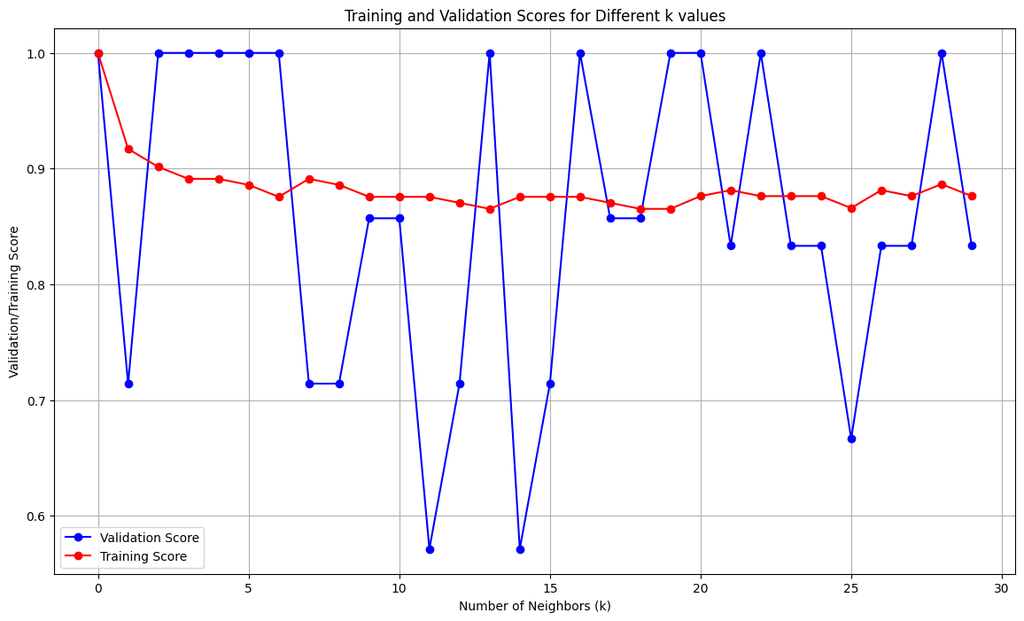

```python
# My code here
optimize_kf = KFold(n_splits = 30, random_state = 42, shuffle = True)
optimize_train_indices_list = []
optimize_test_indices_list = []
optimize_validation_score_list = []
optimize_training_score_list = []
k_list = []
# print(kf.split(normalized_trainFeats))
# print(enumerate(kf.split(normalized_trainFeats)))

for k, (optimize_train_indices, optimize_test_indices) in enumerate(optimize_kf.split(normalized_trainFeats)):
  Update_KNN_model = KNeighborsClassifier(n_neighbors = k + 1)
  Update_KNN_model.fit(normalized_trainFeats, train_label_list)
  # num_train_examples = len(train_indices)
  # num_test_examples = len(test_indices)
  optimize_normalized_trainFeats = normalized_trainFeats[optimize_train_indices]
  optimize_normalized_testFeats = normalized_testFeats[optimize_test_indices]
  #print(split_normalized_trainFeats)

  optimize_training_label = train_label_arr[optimize_train_indices]
  optimize_validation_label = test_label_arr[optimize_test_indices]
  # split_validation_label = test_label_arr[knn_test_indices]
  # print(split_validation_label)

  Optimize_KNN_Validation_Score = Update_KNN_model.score(optimize_normalized_testFeats, optimize_validation_label)
  optimize_validation_score_list.append(Optimize_KNN_Validation_Score)
  #print("Using k-nearest neighbors classifier, Training Score on the training set:", KNN_Training_Score)
  print(f"Split #{k + 1} (k = {k + 1}) Validation Score: {optimize_validation_score_list[k]:.4f}")

  Optimize_KNN_Training_Score = Update_KNN_model.score(optimize_normalized_trainFeats, optimize_training_label)
  optimize_training_score_list.append(Optimize_KNN_Training_Score)
  #print("Using k-nearest neighbors classifier, Training Score on the training set:", KNN_Training_Score)
  print(f"Split #{k + 1} (k = {k + 1}) Training Score: {optimize_training_score_list[k]:.4f}")

  k_list.append(k)
  print("___________________________________________________________________________________________\n\n\n")

plt.figure(figsize=(14, 8))
plt.plot(k_list, optimize_validation_score_list, '-o', color = 'blue', label = 'Validation Score')
plt.plot(k_list, optimize_training_score_list, '-o', color = 'red', label = 'Training Score')
plt.xlabel('Number of Neighbors (k)')
plt.ylabel('Validation/Training Score')
plt.title('Training and Validation Scores for Different k values')
plt.legend()
plt.grid(True)
plt.show()
```

**My Answer Here:**

**The tendency of the Validation Scores keeps jumping all over the place.** Because the relative number of folds to each k is only 1, so the sample is too tiny to be representative. However, each fold has different distributions, and individual noise sensitivity is also distinct. That's why small folds related to each k should arouse some biases. We may increase the number of folds related to each k to achieve a smooth tendency of validation scores to observe.

#### 3b

A better way we can perform this Model Selection is by creating 10 folds. Then, for each `k`, we perform 10-fold cross-validation (each *k* will have the same folds) as we did before in question 4.1 and 4.2. Plot the mean training and validation scores for each *k* using this method of model selection. Use the same formatting as question 4.3.a (4 pts)

```
K = 1: Mean Training Score = 1.0000, Mean Validation Score = 0.8300
K = 2: Mean Training Score = 0.9172, Mean Validation Score = 0.7850
K = 3: Mean Training Score = 0.9067, Mean Validation Score = 0.8650
K = 4: Mean Training Score = 0.8867, Mean Validation Score = 0.8500
K = 5: Mean Training Score = 0.8928, Mean Validation Score = 0.8550
K = 6: Mean Training Score = 0.8861, Mean Validation Score = 0.8350
K = 7: Mean Training Score = 0.8822, Mean Validation Score = 0.8800
K = 8: Mean Training Score = 0.8844, Mean Validation Score = 0.8700
K = 9: Mean Training Score = 0.8822, Mean Validation Score = 0.8700
K = 10: Mean Training Score = 0.8794, Mean Validation Score = 0.8700
K = 11: Mean Training Score = 0.8722, Mean Validation Score = 0.8600
K = 12: Mean Training Score = 0.8711, Mean Validation Score = 0.8700
K = 13: Mean Training Score = 0.8744, Mean Validation Score = 0.8650
K = 14: Mean Training Score = 0.8728, Mean Validation Score = 0.8700
K = 15: Mean Training Score = 0.8728, Mean Validation Score = 0.8650
K = 16: Mean Training Score = 0.8717, Mean Validation Score = 0.8600
K = 17: Mean Training Score = 0.8728, Mean Validation Score = 0.8550
K = 18: Mean Training Score = 0.8672, Mean Validation Score = 0.8550
K = 19: Mean Training Score = 0.8689, Mean Validation Score = 0.8600
K = 20: Mean Training Score = 0.8733, Mean Validation Score = 0.8750
K = 21: Mean Training Score = 0.8750, Mean Validation Score = 0.8650
K = 22: Mean Training Score = 0.8728, Mean Validation Score = 0.8700
K = 23: Mean Training Score = 0.8750, Mean Validation Score = 0.8700
K = 24: Mean Training Score = 0.8711, Mean Validation Score = 0.8650
K = 25: Mean Training Score = 0.8761, Mean Validation Score = 0.8700
K = 26: Mean Training Score = 0.8767, Mean Validation Score = 0.8700
K = 27: Mean Training Score = 0.8800, Mean Validation Score = 0.8850
K = 28: Mean Training Score = 0.8789, Mean Validation Score = 0.8800
K = 29: Mean Training Score = 0.8772, Mean Validation Score = 0.8800
K = 30: Mean Training Score = 0.8767, Mean Validation Score = 0.8700
```

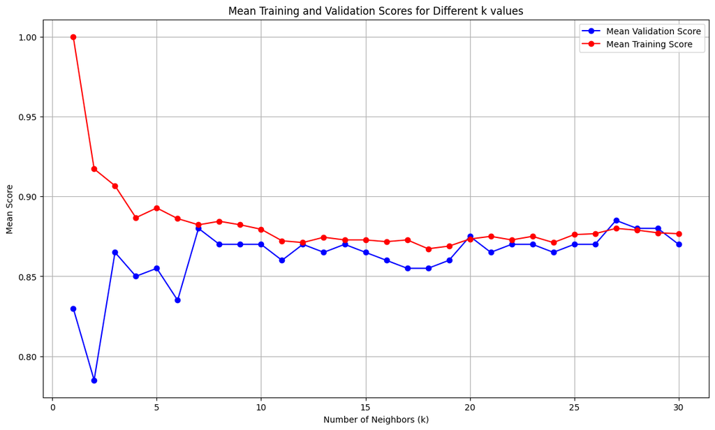

```python
# My code here
# Initialize variables
kf = KFold(n_splits = 10, random_state = 42, shuffle = True)

### Because Loop always starts from 0, but the value of k shouldn't start from 0, it should starts from 1
k_values = range(1, 31)

Mean_Validation_Scores = []
Mean_Training_Scores = []

# Iterate over each k value
for k in k_values:
    validation_scores_list = []
    training_scores_list = []

    # Perform 10-fold cross-validation
    for train_indices, test_indices in kf.split(normalized_trainFeats):
        Update_KNN_Model = KNeighborsClassifier(n_neighbors = k)
        Update_KNN_Model.fit(normalized_trainFeats[train_indices], train_label_arr[train_indices])

        # Compute scores
        training_score = Update_KNN_Model.score(normalized_trainFeats[train_indices], train_label_arr[train_indices])
        validation_score = Update_KNN_Model.score(normalized_trainFeats[test_indices], train_label_arr[test_indices])

        # Append scores to lists
        validation_scores_list.append(validation_score)
        training_scores_list.append(training_score)

    # Compute mean scores for this k value
    mean_validation_score = np.mean(validation_scores_list)
    mean_training_score = np.mean(training_scores_list)

    # Append mean scores to lists
    Mean_Validation_Scores.append(mean_validation_score)
    Mean_Training_Scores.append(mean_training_score)

    # Print mean scores for each k
    print(f"K = {k}: Mean Training Score = {mean_training_score:.4f}, Mean Validation Score = {mean_validation_score:.4f}")

# Plotting
plt.figure(figsize=(14, 8))
plt.plot(k_values, Mean_Validation_Scores, '-o', color='blue', label='Mean Validation Score')
plt.plot(k_values, Mean_Training_Scores, '-o', color='red', label='Mean Training Score')
plt.xlabel('Number of Neighbors (k)')
plt.ylabel('Mean Score')
plt.title('Mean Training and Validation Scores for Different k values')
plt.grid(True)
plt.legend()
plt.show()
```

#### 3c

What is the optimal *k* value? (1 pts)

```python
# My code here
Max_Validation_Score = np.max(Mean_Validation_Scores)
optimal_k_value = Mean_Validation_Scores.index(Max_Validation_Score) + 1
print("The optimal k value:", optimal_k_value)
```

```
The optimal k value: 27
```

**My Answer Here:**

The optimal k value: **27**

#### 3d

Explain why *k*-NN generally overfits less with higher values of *k*. (2 pts)

**My Answer Here:**

When k or the number of neighbors is too small, the model selects only the values closest to the data sample, generating the above-described extremely complicated decision boundary—poor performance results from such a model's inability to generalize adequately on the test data set.

By adjusting the value of the n_neighbors option, we can fix the problem mentioned above. The model begins to generalize better with smooth decision boundaries as the number of neighbors increases; however, raising the value too much will cause the performance to decline again.

### 4

Now that we know the "best" *k*, train a new *k*-NN model with it using the entirety of the training data and evaluate it on the testing data.

```python
# My code here
Entire_KNN_model = KNeighborsClassifier(n_neighbors = 27)
Entire_KNN_model.fit(normalized_trainFeats, train_label_list)

# Entire_KNN_Training_Score = Entire_KNN_model.score(normalized_trainFeats, train_label_list)
# print("Using 27-nearest neighbors classifier, Training Score on the entirety of training set:", Entire_KNN_Training_Score)
```

```
KNeighborsClassifier(n_neighbors=27)
```

#### 4a

What is the testing score? (1 pts)

```python
#your code here
Entire_KNN_Testing_Score = Entire_KNN_model.score(normalized_testFeats, test_label_list)
print("Using 27-nearest neighbors classifier, Testing Score on the entirety of testing set:", Entire_KNN_Testing_Score)
```

```
Using 27-nearest neighbors classifier, Testing Score on the entirety of testing set: 0.8833333333333333
```

**My answer Here:**

Using 27-nearest neighbors classifier, Testing Score on the entirety of testing set: **0.8833333333333333**

#### 4b

How does this score compare with the 1-NN model from question 3.3? Is it the best of the three models you trained in Section 3? (2 pts)

**My Answer Here:**

**Obviously, 27-NN greatly improves the testing score compared to 1-NN model from question (3.3).**

But it still not the best of the three models I trained in Section 3, using Support Vector Machine (SVM) provides a higher Testing Score = 0.8857142857142857 > 0.8833333333333333

# Extra Credit (but you should really do it because it will be useful eventually!) for 4 points

Make a function for relative bandpower! 2 point

**Reference:**

**[1]** https://docs.scipy.org/doc/scipy/reference/generated/scipy.signal.welch.html

**[2]** https://numpy.org/doc/stable/reference/generated/numpy.logical_and.html

```python
def rel_bandpower(data, sample_rate, win, min_freq, max_freq):
    """
    Function that computes the relative power in a band [fmin, fmax]

    Idea:
    A simple way to do this is to first compute an estimate of the power spectral density (using something like Welch's Periodogram).
    Then you would specify which range of frequency you are interested in.
    To take the average band power you would then find the area under the curve for this frequency range in Welch's Periodogram.
    Since we are interested in relative band power - we want to understand what % of our total power is in our specified frequency band.
    """
    ### PSD : Power Spectral Density (PSD)
    freqs, PSD = sig.welch(data, sample_rate, nperseg = win)
    # print(freqs)
    # print(PSD)

    # Find indices corresponding to frequency range\
    ### Boolean result of the logical AND operation applied to the elements of min_freq and max_freq
    band_indices = np.logical_and(freqs >= min_freq, freqs <= max_freq)

    # Integrate along the given axis using the composite trapezoidal rule
    total_power = np.trapz(PSD, x = freqs)
    band_power = np.trapz(PSD[band_indices], x=freqs[band_indices])

    # Compute relative band power as a percentage
    relative_band_power = (band_power / total_power) * 100

    return freqs, PSD, relative_band_power
```

Show us how a snippet of the raw EEG signal before looks like using Welch's Periodogram and report an example of how your rel_bandpower function works. - 1 point

Choose your own frequency bands and time frame.

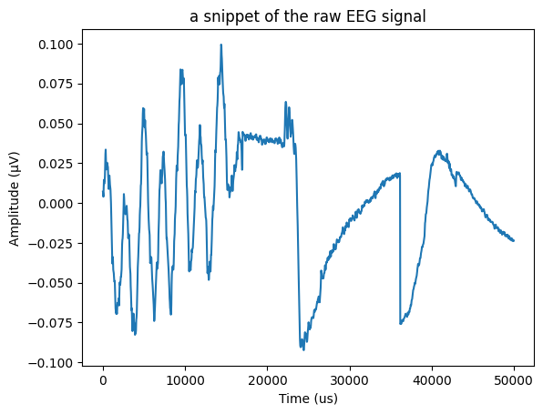

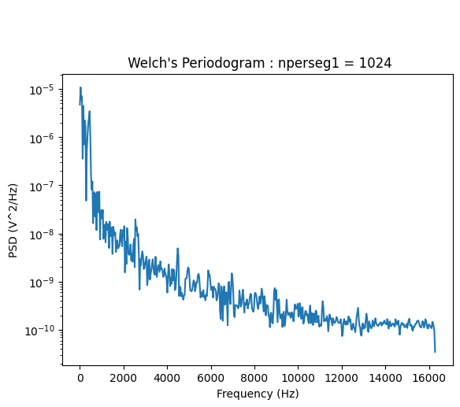

```
 When nperseg1 = 1024 : 95.47911224917578 % of our total power is in our specified frequency band [0, 500]
```

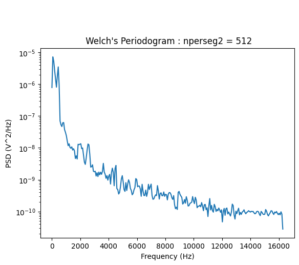

```
 When nperseg2 = 512 : 86.32607992796176 % of our total power is in our specified frequency band [0, 500]
```

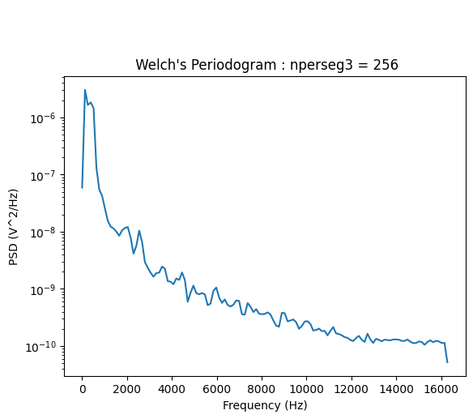

```
 When nperseg3 = 256 : 66.72432800357244 % of our total power is in our specified frequency band [0, 500]
```

```python
# My Code Here
# print(training_data)
### snippet_time(s)
nperseg1 = 1024

### relative power in a band [fmin, fmax]
relative_power = [0, 500]
snippet_time = 0.05
snippet = int(snippet_time * training_sample_rate)
snippet_training_data = training_data[0:snippet]
snippet_training_data = snippet_training_data.reshape(-1)
# print(snippet_training_data)
# print(len(snippet_training_data))
snippet_time_range = np.arange(training_start_time, snippet_time * 10**6, (snippet_time * 10**6 - training_start_time) / len(snippet_training_data))

plt.title("a snippet of the raw EEG signal")
plt.xlabel('Time (us)')
plt.ylabel('Amplitude (μV)')
plt.plot(snippet_time_range, snippet_training_data)
plt.show()

frequency1, PSD1, relative_bandpower1 = rel_bandpower(snippet_training_data, training_sample_rate, nperseg1, min(relative_power), max(relative_power))
plt.semilogy(frequency1, PSD1)
plt.title("\n\n\n Welch's Periodogram : nperseg1 = 1024")
plt.xlabel('Frequency (Hz)')
plt.ylabel('PSD (V^2/Hz)')
plt.show()
print("\n When nperseg1 = 1024 :", relative_bandpower1, "% of our total power is in our specified frequency band [0, 500]")

nperseg2 = 512
frequency2, PSD2, relative_bandpower2 = rel_bandpower(snippet_training_data, training_sample_rate, nperseg2, min(relative_power), max(relative_power))
plt.semilogy(frequency2, PSD2)
plt.title("\n\n\n Welch's Periodogram : nperseg2 = 512")
plt.xlabel('Frequency (Hz)')
plt.ylabel('PSD (V^2/Hz)')
plt.show()
print("\n When nperseg2 = 512 :", relative_bandpower2, "% of our total power is in our specified frequency band [0, 500]")

nperseg3 = 256
frequency3, PSD3, relative_bandpower3 = rel_bandpower(snippet_training_data, training_sample_rate, nperseg3, min(relative_power), max(relative_power))
plt.semilogy(frequency3, PSD3)
plt.title("\n\n\n Welch's Periodogram : nperseg3 = 256")
plt.xlabel('Frequency (Hz)')
plt.ylabel('PSD (V^2/Hz)')
plt.show()
print("\n When nperseg3 = 256 :", relative_bandpower3, "% of our total power is in our specified frequency band [0, 500]")
```

**My Answer Here:**

The plot above shows how Welch's Periodogram works with different value of npersegs(different number of windows).

Explain the difference between absolute and relative band power. What are some cases where absolute power would give you a misleading answer? - 1 point

**My Answer Here:**

**Relative band power, which provides a normalized metric, conveys the power of the overall power of the signal. In contrast, absolute band power shows the raw power level inside a particular frequency band.**

Absolute power can be deceptive when comparing signals with varying overall power levels or in situations where normalization is required, even while it provides valuable information about the intensity of the signal within a particular frequency band.

In fields like EEG or ECG analysis, where inter-subject variability and normalization are critical considerations, relative band power is beneficial for comparative analyses across different signals or experimental conditions because it provides a standardized metric that accounts for variations in total power.

Reference:

**[1]** Title: "Difference Between Absolute and Relative Laser Power Measurements"

Website: Gentec Electro-Optics Blog

URL: https://www.gentec-eo.com/blog/difference-between-absolute-and-relative-laser-power-measurements